# ABD_2001-2024_Gasoline-Prices-Visualization-Analysis

# Farklı Bölgelerde Zaman İçinde Benzin Fiyatları

### Çoklu Zaman Serisi Grafiği

- **Ekonomik ve Sosyal Olayların Etkisi:** Küresel ve yerel ekonomik olayların benzin fiyatları üzerindeki etkisi incelenebilir.
- **Politika ve Regülasyonların Etkisi:** Hükümet politikalarının ve düzenlemelerin benzin fiyatları üzerindeki etkisini anlamak için kullanılabilir.

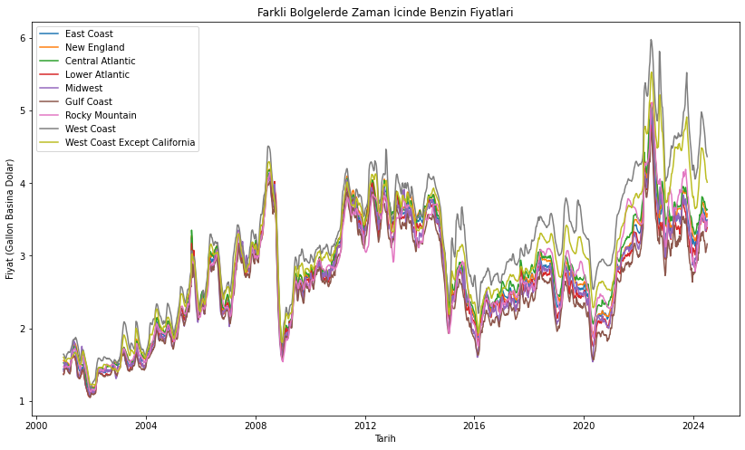

```python
# Sütun isimlerini kısaltırız, legend'e uygun
columns_new1 = {
    'Weekly East Coast All Grades All Formulations Retail Gasoline Prices  (Dollars per Gallon)': 'East Coast',
    'Weekly New England (PADD 1A) All Grades All Formulations Retail Gasoline Prices  (Dollars per Gallon)': 'New England',
    'Weekly Central Atlantic (PADD 1B) All Grades All Formulations Retail Gasoline Prices  (Dollars per Gallon)': 'Central Atlantic',
    'Weekly Lower Atlantic (PADD 1C) All Grades All Formulations Retail Gasoline Prices  (Dollars per Gallon)': 'Lower Atlantic',
    'Weekly Midwest All Grades All Formulations Retail Gasoline Prices  (Dollars per Gallon)': 'Midwest',
    'Weekly Gulf Coast All Grades All Formulations Retail Gasoline Prices  (Dollars per Gallon)': 'Gulf Coast',
    'Weekly Rocky Mountain All Grades All Formulations Retail Gasoline Prices  (Dollars per Gallon)': 'Rocky Mountain',
    'Weekly West Coast All Grades All Formulations Retail Gasoline Prices  (Dollars per Gallon)': 'West Coast',
    'Weekly West Coast (PADD 5) Except California All Grades All Formulations Retail Gasoline Prices  (Dollars per Gallon)': 'West Coast Except California'
}

fuel_Regions = fuel_Regions.rename(columns=columns_new1)


# coklu zaman serisi grafigi uygulaması
plt.figure(figsize=(14, 8))
sns.lineplot(data=fuel_Regions, x='Date', y='East Coast', label='East Coast')
sns.lineplot(data=fuel_Regions, x='Date', y='New England', label='New England')
sns.lineplot(data=fuel_Regions, x='Date', y='Central Atlantic', label='Central Atlantic')
sns.lineplot(data=fuel_Regions, x='Date', y='Lower Atlantic', label='Lower Atlantic')
sns.lineplot(data=fuel_Regions, x='Date', y='Midwest', label='Midwest')
sns.lineplot(data=fuel_Regions, x='Date', y='Gulf Coast', label='Gulf Coast')
sns.lineplot(data=fuel_Regions, x='Date', y='Rocky Mountain', label='Rocky Mountain')
sns.lineplot(data=fuel_Regions, x='Date', y='West Coast', label='West Coast')
sns.lineplot(data=fuel_Regions, x='Date', y='West Coast Except California', label='West Coast Except California')
plt.title('Farkli Bolgelerde Zaman İcinde Benzin Fiyatlari')
plt.xlabel('Tarih')
plt.ylabel('Fiyat (Gallon Basina Dolar)')
plt.legend()
plt.show()
```

- **Grafiğe göre,**
  - Genel Trendler: Tüm bölgelerde genel olarak benzer trendler gözlemleniyor, grafikte 2008 yılında etki eden faktör nedeniyle tüm bölgelerde benzin fiyatlarında ani bir artış ve ardından düşüş görülüyor.
  - Bölgesel Farklılıklar: Bazı bölgelerde fiyat dalgalanmalarının diğer bölgelerden daha belirgin olduğu görülebilir. Grafiğe göre West Coast (Batı Kıyısı) bölgesinde fiyatlar genellikle diğer bölgelere göre daha yüksek seyretmektedir.

# Bölgelere Göre Benzin Fiyat Dağılımı

### Box Plot

- Verinin merkezi eğilim ve yayılımını görselleştirmek için kullanılır.
  - Her bölgenin, Minimum, ilk çeyrek (Q1), medyan (Q2), üçüncü çeyrek (Q3) ve maksimum değerleri gösterir. Ayrıca, aykırı uç değerler de işaretlenmiştir.

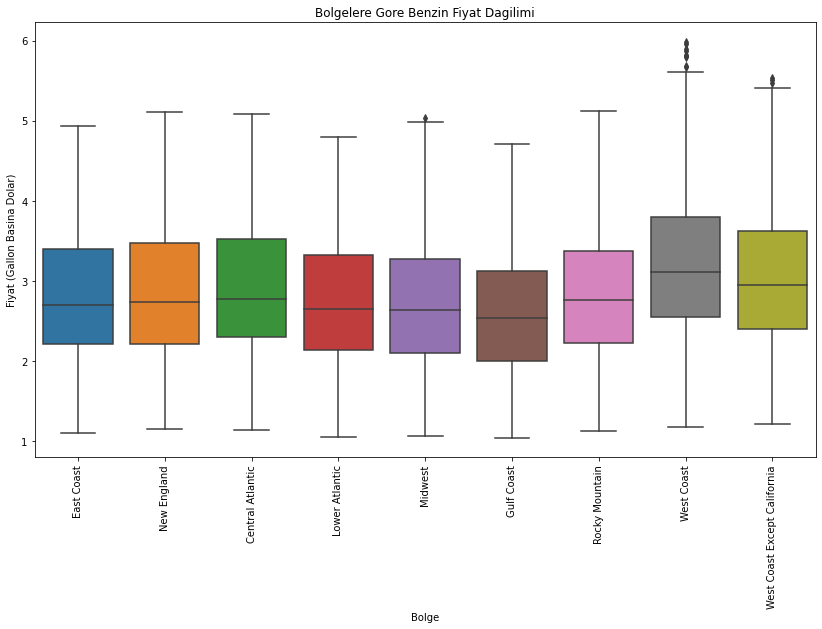

```python
plt.figure(figsize=(14, 8))
regions = ['East Coast', 'New England', 'Central Atlantic', 'Lower Atlantic', 'Midwest', 'Gulf Coast', 'Rocky Mountain', 'West Coast', 'West Coast Except California']

fuel_Region1 = fuel_Regions.melt(id_vars='Date', value_vars=regions, var_name='Region', value_name='Price')

sns.boxplot(data=fuel_Region1, x='Region', y='Price')
plt.title('Bolgelere Gore Benzin Fiyat Dagilimi')
plt.xlabel('Bolge')
plt.ylabel('Fiyat (Gallon Basina Dolar)')
plt.xticks(rotation=90)
plt.show()
```

- **Merkezi Eğilim (Medyan):** Her kutunun içindeki çizgi, o bölgedeki benzin fiyatlarının medyanını gösterir. Grafiğe göre, West Coast bölgesinde medyan fiyat diğer bölgelere göre daha yüksektir.
- **Yayılım:** Kutuların uzunluğu, verinin yayılımını gösterir. Daha uzun kutular, fiyatların daha geniş bir aralıkta değiştiğini gösterir.
- **Aykırı Uç Değerler:** Kutuların dışında bulunan noktalar, aykırı uç değerleri temsil eder. Grafikte bazı bölgelerdeki yüksek fiyatlar bu noktalarla işaretlenmiştir.
- **Maksimum ve Minimum Değerler:** Her bir kutunun üst ve alt çizgileri, ilgili bölgedeki en yüksek ve en düşük fiyatları gösterir.

# Bölgelere Göre Benzin Fiyatları

# Density plot

- Sürekli bir değişkenin dağılımını gösterir ve veri noktalarının yoğunluğunu görselleştirmek için kullanılır

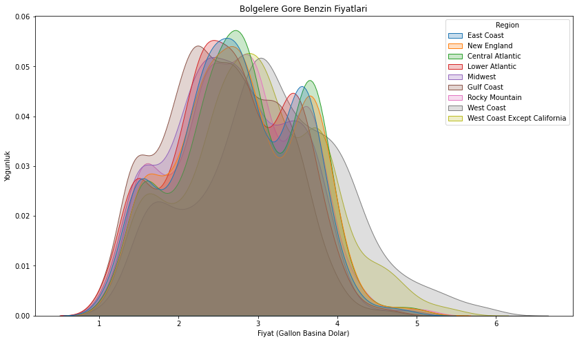

```python
plt.figure(figsize=(14, 8))
sns.kdeplot(data=fuel_Region1, x='Price', hue='Region', fill=True)
plt.title('Bolgelere Gore Benzin Fiyatlari')
plt.xlabel('Fiyat (Gallon Basina Dolar)')
plt.ylabel('Yogunluk')
plt.show()
```

Grafik, çeşitli bölgelerde benzin fiyatlarının nasıl dağıldığını ve hangi fiyatların daha sık görüldüğünü görselleştirir. Örneğin, bazı bölgelerde benzin fiyatları genellikle daha düşük seviyelerde yoğunlaşırken, diğerlerinde daha yüksek fiyat seviyelerinde yoğunlaşabilir. Bu tür bir grafik, bölgesel farklılıkların anlaşılmasına yardımcı olabilir.

```python
fuel_Prices.head()
```

|  | Date | Weekly U.S. All Grades All Formulations Retail Gasoline Prices (Dollars per Gallon) | Weekly U.S. All Grades Conventional Retail Gasoline Prices (Dollars per Gallon) | Weekly U.S. All Grades Reformulated Retail Gasoline Prices (Dollars per Gallon) | Weekly U.S. Regular All Formulations Retail Gasoline Prices (Dollars per Gallon) | Weekly U.S. Regular Conventional Retail Gasoline Prices (Dollars per Gallon) | Weekly U.S. Regular Reformulated Retail Gasoline Prices (Dollars per Gallon) | Weekly U.S. Midgrade All Formulations Retail Gasoline Prices (Dollars per Gallon) | Weekly U.S. Midgrade Conventional Retail Gasoline Prices (Dollars per Gallon) | Weekly U.S. Midgrade Reformulated Retail Gasoline Prices (Dollars per Gallon) | Weekly U.S. Premium All Formulations Retail Gasoline Prices (Dollars per Gallon) | Weekly U.S. Premium Conventional Retail Gasoline Prices (Dollars per Gallon) | Weekly U.S. Premium Reformulated Retail Gasoline Prices (Dollars per Gallon) | Weekly U.S. No 2 Diesel Retail Prices (Dollars per Gallon) | Weekly U.S. No 2 Diesel Ultra Low Sulfur (0-15 ppm) Retail Prices (Dollars per Gallon) | Weekly U.S. No 2 Diesel Low Sulfur (15-500 ppm) Retail Prices (Dollars per Gallon) |
| --- | --- | --- | --- | --- | --- | --- | --- | --- | --- | --- | --- | --- | --- | --- | --- | --- |
| 0 | 2001-01-01 | 1.446 | 1.416 | 1.558 | 1.406 | 1.377 | 1.489 | 1.503 | 1.467 | 1.628 | 1.590 | 1.559 | 1.704 | 1.522 | NaN | NaN |
| 1 | 2001-01-08 | 1.465 | 1.439 | 1.558 | 1.425 | 1.400 | 1.492 | 1.523 | 1.492 | 1.628 | 1.606 | 1.581 | 1.696 | 1.520 | NaN | NaN |
| 2 | 2001-01-15 | 1.513 | 1.497 | 1.569 | 1.474 | 1.458 | 1.511 | 1.566 | 1.546 | 1.631 | 1.656 | 1.639 | 1.710 | 1.509 | NaN | NaN |
| 3 | 2001-01-22 | 1.511 | 1.496 | 1.565 | 1.471 | 1.456 | 1.509 | 1.562 | 1.543 | 1.627 | 1.656 | 1.640 | 1.708 | 1.528 | NaN | NaN |
| 4 | 2001-01-29 | 1.500 | 1.486 | 1.554 | 1.460 | 1.446 | 1.497 | 1.551 | 1.533 | 1.616 | 1.644 | 1.628 | 1.697 | 1.539 | NaN | NaN |